# nobel_prize_data_analysis_case_study

## 1️⃣ Table of Contents

1. Environment Setup & Data Loading
2. Data Overview and Quality Checks
3. Q1 — Most common gender
4. Q2 — Country with most laureates
5. Q3 — US proportion by decade
6. Q4 — Female proportion by decade & category
7. Q5 — First Female laureate
8. Q6 — Repeat winners
9. Q7 — Female representation over time
10. Q8 — Gender disparity by category
11. Findings
12. Appendix

# 2️⃣ Nobel Prize Data Analysis – Exploratory Case Study

**Author:** Andreza Eufrasio

**Tools:** Python, Pandas, Matplotlib, Seaborn

**Dataset Source:** Nobel Prize Foundation / DataCamp dataset

**Dataset Summary:**

- **Total records:** ~1,000 Nobel Prize laureates
- **Time span:** Early 1900s – 2023
- **Prize categories:** Physics, Chemistry, Medicine, Literature, Peace, and Economics
- **Laureate types:** Individuals and organizations

# 3️⃣ Introduction

> The Nobel Prize is one of the most prestigious international awards, recognizing outstanding achievements in Physics, Chemistry, Medicine, Literature, Peace, and Economic Sciences.

> This project explores historical Nobel Prize winner data to identify patterns in gender representation, geographic distribution of laureates, and trends across decades.

# 4️⃣ Goal

> Analyze Nobel Prize data to explore patterns in **gender representation**, **geographic distribution of laureates**, and **temporal trends across decades** using exploratory data analysis techniques.

[figure not shown]

*Figure 1: Nobel Prize medal representing the prestigious award given annually for outstanding contributions to science, literature, and peace.*

# 5️⃣ Key Questions

This analysis aims to answer the following questions:

1. What is the most commonly awarded gender among Nobel Prize winners?
2. Which country has produced the most Nobel laureates?
3. Which decade had the highest proportion of US-born winners?
4. Which decade and Nobel Prize category had the highest proportion of female laureates?
5. Who was the first woman to receive a Nobel Prize and in which category?
6. Which individuals have won multiple Nobel Prizes?
7. How has female representation among Nobel Prize winners evolved over time?
8. Which Nobel Prize categories show the largest gender disparities?

## Deliverables

- Clear answers to the questions above, with **visualizations.**
- Clean, **reproducible notebook** following best practices.

## Dataset

The dataset contains historical records of Nobel Prize laureates, including information about the prize category, year of award, and biographical details of the winners.

| Column | Description |
| --- | --- |
| `year` | Year in which the Nobel Prize was awarded |
| `category` | Nobel Prize category (Physics, Chemistry, Medicine, Literature, Peace, Economics) |
| `prize` | Official name of the Nobel Prize awarded |
| `motivation` | Citation describing the reason the Nobel Prize was awarded |
| `prize_share` | Fraction of the prize awarded to the laureate (e.g., 1/2, 1/3) |
| `laureate_id` | Unique identifier assigned to each laureate |
| `laureate_type` | Indicates whether the laureate is an **individual** or an **organization** |
| `full_name` | Full name of the laureate |
| `birth_date` | Date of birth of the laureate |
| `birth_city` | City where the laureate was born |
| `birth_country` | Country where the laureate was born |
| `sex` | Gender of the laureate |
| `organization_name` | Name of the organization associated with the laureate (if applicable) |
| `organization_city` | City where the organization is located |
| `organization_country` | Country where the organization is located |
| `death_date` | Date of death of the laureate (if applicable) |
| `death_city` | City where the laureate died |
| `death_country` | Country where the laureate died |

```
**Dataset Source:** Nobel Prize Foundation / DataCamp dataset
```

# 6️⃣ Analysis Type

Exploratory Data Analysis (EDA)

```python
!python --version
```

```
Python 3.12.7
```

## 1) Environment Setup & Data Loading

```python
# In this section, we import the required Python libraries and load the Nobel Prize dataset into a pandas DataFrame for analysis.

import pandas as pd
import seaborn as sns
import numpy as np
import matplotlib.pyplot as plt
```

```python
# Expect a file named 'nobel.csv' in the same folder.
data = pd.read_csv("nobel.csv")

data.head()
```

|  | year | category | prize | motivation | prize_share | laureate_id | laureate_type | full_name | birth_date | birth_city | birth_country | sex | organization_name | organization_city | organization_country | death_date | death_city | death_country |
| --- | --- | --- | --- | --- | --- | --- | --- | --- | --- | --- | --- | --- | --- | --- | --- | --- | --- | --- |
| 0 | 1901 | Chemistry | The Nobel Prize in Chemistry 1901 | "in recognition of the extraordinary services ... | 1/1 | 160 | Individual | Jacobus Henricus van 't Hoff | 1852-08-30 | Rotterdam | Netherlands | Male | Berlin University | Berlin | Germany | 1911-03-01 | Berlin | Germany |
| 1 | 1901 | Literature | The Nobel Prize in Literature 1901 | "in special recognition of his poetic composit... | 1/1 | 569 | Individual | Sully Prudhomme | 1839-03-16 | Paris | France | Male | NaN | NaN | NaN | 1907-09-07 | Châtenay | France |
| 2 | 1901 | Medicine | The Nobel Prize in Physiology or Medicine 1901 | "for his work on serum therapy, especially its... | 1/1 | 293 | Individual | Emil Adolf von Behring | 1854-03-15 | Hansdorf (Lawice) | Prussia (Poland) | Male | Marburg University | Marburg | Germany | 1917-03-31 | Marburg | Germany |
| 3 | 1901 | Peace | The Nobel Peace Prize 1901 | NaN | 1/2 | 462 | Individual | Jean Henry Dunant | 1828-05-08 | Geneva | Switzerland | Male | NaN | NaN | NaN | 1910-10-30 | Heiden | Switzerland |
| 4 | 1901 | Peace | The Nobel Peace Prize 1901 | NaN | 1/2 | 463 | Individual | Frédéric Passy | 1822-05-20 | Paris | France | Male | NaN | NaN | NaN | 1912-06-12 | Paris | France |

## 2) Data Quality Checks

> Before performing the analysis, we inspect the dataset structure and evaluate potential data quality issues such as missing values and data types. This step ensures that the data used in the analysis is reliable and suitable for exploratory analysis.

# Basic Info (rows, columns)

```python
# Basic info
print(f" Rows: {data.shape[0]}  and Columns: {data.shape[1]}","\n" )


# Inspect dataset structure
data.info()
```

```
 Rows: 1000  and Columns: 18

<class 'pandas.core.frame.DataFrame'>
RangeIndex: 1000 entries, 0 to 999
Data columns (total 18 columns):
 #   Column                Non-Null Count  Dtype
---  ------                --------------  -----
 0   year                  1000 non-null   int64
 1   category              1000 non-null   object
 2   prize                 1000 non-null   object
 3   motivation            912 non-null    object
 4   prize_share           1000 non-null   object
 5   laureate_id           1000 non-null   int64
 6   laureate_type         1000 non-null   object
 7   full_name             1000 non-null   object
 8   birth_date            968 non-null    object
 9   birth_city            964 non-null    object
 10  birth_country         969 non-null    object
 11  sex                   970 non-null    object
 12  organization_name     736 non-null    object
 13  organization_city     735 non-null    object
 14  organization_country  735 non-null    object
 15  death_date            596 non-null    object
 16  death_city            579 non-null    object
 17  death_country         585 non-null    object
dtypes: int64(2), object(16)
memory usage: 140.8+ KB
```

> The dataset contains 1000 observations and 18 variables. Most variables are stored as object types, while the year and laureate_id columns are numeric. The info() output also reveals that some columns contain missing values, particularly in the death-related and organization-related fields.

# Assess missing values

```python
# checking missing values
data.isna().sum()
```

[output not shown]

> The dataset contains missing values in several columns. The largest number of missing entries appears in the **death_date**, **death_city**, and **death_country** variables, which is expected since many Nobel laureates may still be alive. Organizational fields also contain missing data because not all laureates are affiliated with institutions.

# Identify Columns with Missing Values

```python
# Identify Columns with Missing Values

missing_values = data.isna().sum()
cols_with_missing_values = missing_values[missing_values > 0]
cols_with_missing_values
```

```
motivation               88
birth_date               32
birth_city               36
birth_country            31
sex                      30
organization_name       264
organization_city       265
organization_country    265
death_date              404
death_city              421
death_country           415
dtype: int64
```

> Columns containing missing values were identified in order to determine which variables require cleaning before analysis. Variables related to death information and organizational affiliation contain the highest number of missing entries and may require special handling depending on the analysis objectives.

# Define Threshold for Acceptable Missing Values

```python
missing_threshold =len(data) * 0.05

#  Drop rows with missing values in important columns
cols_to_drop = data.columns[data.isna().sum() <= missing_threshold]
cols_to_drop
```

[output not shown]

> A threshold of 5% missing values was defined to determine which columns are important for the analysis. Columns with ≤ 5% missing values were treated as essential variables, and rows containing missing data in those columns were removed using dropna(). This approach ensures that key variables such as year, category, full_name, and sex remain complete while preserving most of the dataset. After applying this cleaning step, the dataset retains 962 observations and 18 columns, indicating that only a small portion of data was affected.

# Handle Missing Values in Key Columns

```python
data.dropna(subset = cols_to_drop, inplace = True)
```

# Verify Dataset Dimensions After Cleaning

```python
data.shape
```

```
(962, 18)
```

# Numeric Summary (min/max)

```python
data.describe()
```

|  | year | laureate_id |
| --- | --- | --- |
| count | 962.000000 | 962.000000 |
| mean | 1973.205821 | 501.142412 |
| std | 34.459122 | 298.458993 |
| min | 1901.000000 | 1.000000 |
| 25% | 1949.000000 | 241.250000 |
| 50% | 1978.500000 | 486.500000 |
| 75% | 2002.000000 | 756.750000 |
| max | 2023.000000 | 1034.000000 |

> The numeric summary provides basic descriptive statistics for the numeric variables in the dataset. The year column ranges from 1901 to 2023, which is consistent with the historical timeline of Nobel Prize awards. No obvious anomalies or outliers appear in the numeric variables, indicating that the dataset is consistent with expected values.

# Detect Placeholder Values in Categorical Columns

```python
# Detect & Count Bad Placeholders in Categorical Columns
bad_values = ["?", "N/A", "NA", "n/a", "Unknown", "unknown", "None", "", " ", "-", "--"]

bad_summary = {}

for col in data.select_dtypes(include=['object','string','category']).columns:
    bad_summary[col] = data[col].isin(bad_values).sum()

pd.Series(bad_summary)
```

```
category                0
prize                   0
motivation              0
prize_share             0
laureate_type           0
full_name               0
birth_date              0
birth_city              0
birth_country           0
sex                     0
organization_name       0
organization_city       0
organization_country    0
death_date              0
death_city              0
death_country           0
dtype: int64
```

> A check for placeholder values such as "NA", "N/A", "unknown", or "None" was performed across categorical columns. These values sometimes appear in datasets as substitutes for missing data. The inspection revealed that no placeholder values are present, indicating that missing data is consistently represented using standard NaN values.

## 3) Q1) What is the most commonly awarded gender among Nobel Prize winners?

```python
gender = data ["sex"].value_counts()
gender
```

```
sex
Male      897
Female     65
Name: count, dtype: int64
```

```python
top_gender = gender.idxmax()
top_gender
```

```
'Male'
```

### Percentage Contribution

```python
gender_percent = data["sex"].value_counts(normalize=True) * 100
gender_percent
gender_percent.round(2)
```

```
sex
Male      93.24
Female     6.76
Name: proportion, dtype: float64
```

### Visualization Using Seaborn

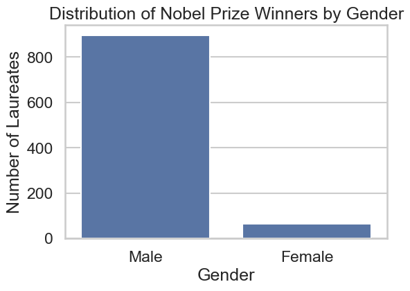

```python
plt.figure(figsize=(6,4))

sns.countplot(data=data, x = "sex")

plt.title("Distribution of Nobel Prize Winners by Gender")
plt.xlabel("Gender")
plt.ylabel("Number of Laureates")


plt.show()
```

## 4) Q2) Which country has produced the most Nobel laureate

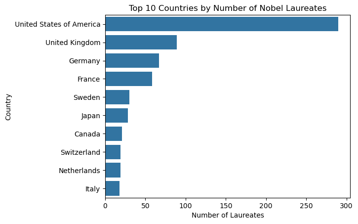

```python
top_countries = data["birth_country"].value_counts().head(10)

sns.barplot(x=top_countries.values, y=top_countries.index)

plt.title("Top 10 Countries by Number of Nobel Laureates")
plt.xlabel("Number of Laureates")
plt.ylabel("Country")

plt.show()
```

```python
country = data["birth_country"].value_counts()
country
```

```
birth_country
United States of America                        290
United Kingdom                                   89
Germany                                          67
France                                           58
Sweden                                           30
                                               ...
Ottoman Empire (Turkey)                           1
Russian Empire (Azerbaijan)                       1
Bosnia (Bosnia and Herzegovina)                   1
Southern Rhodesia (Zimbabwe)                      1
French protectorate of Tunisia (now Tunisia)      1
Name: count, Length: 128, dtype: int64
```

### Find the Top Country

```python
top_country = country.idxmax()
top_country
```

```
'United States of America'
```

### Percentage Contribution

```python
country_percent = data["birth_country"].value_counts(normalize=True) * 100
country_percent
country_percent.round(2)
```

```
birth_country
United States of America                        30.15
United Kingdom                                   9.25
Germany                                          6.96
France                                           6.03
Sweden                                           3.12
                                                ...
Ottoman Empire (Turkey)                          0.10
Russian Empire (Azerbaijan)                      0.10
Bosnia (Bosnia and Herzegovina)                  0.10
Southern Rhodesia (Zimbabwe)                     0.10
French protectorate of Tunisia (now Tunisia)     0.10
Name: proportion, Length: 128, dtype: float64
```

> **Insight:** The United States has produced the largest number of Nobel Prize laureates, accounting for approximately **30% of all winners** in the dataset. The United Kingdom and Germany follow as the second and third most represented countries. This distribution reflects the strong presence of research institutions and scientific infrastructure in these countries over the past century.

## 5) Q3) Which decade had the highest proportion of US-born winners?

### Create the decade variable

```python
# It converts a year into its deacde
data["decade"] = (data["year"] //10 * 10)
```

### Creates the US-born boolean variable

```python
# Identify US-born laureates
data["US_born"] = data["birth_country"] == "United States of America"
```

### Compute proportion by decade

```python
# This groups rows by decade and calculates the mean of the boolean
usa_ratio_by_decade  = data.groupby("decade")["US_born"].mean()
usa_ratio_by_decade
```

```
decade
1900    0.017857
1910    0.078947
1920    0.074074
1930    0.254545
1940    0.325000
1950    0.295775
1960    0.280000
1970    0.320388
1980    0.329787
1990    0.415842
2000    0.444444
2010    0.324561
2020    0.409091
Name: US_born, dtype: float64
```

### Identify the peak decade

```python
# idxmax() returns the index where the maximum value occurs.
max_decade_usa = usa_ratio_by_decade.idxmax()
max_decade_usa
```

```
2000
```

> **Insight:**

The proportion of US-born Nobel Prize winners increases significantly after the mid-20th century. The 2000s show the highest proportion, highlighting the growing influence of US research institutions in global scientific leadership.

### Visualization Using Seaborn

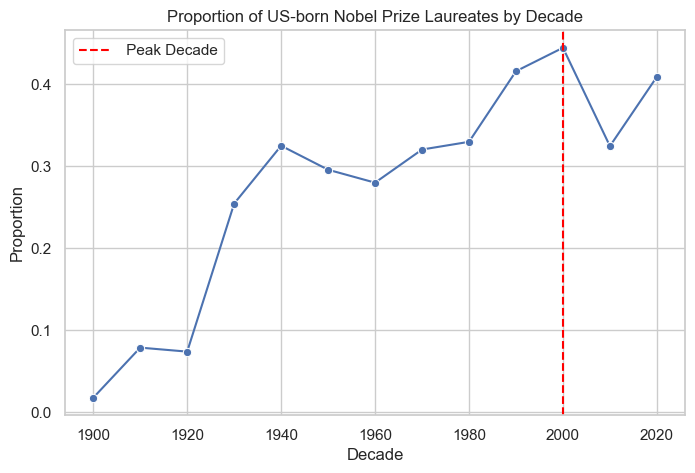

```python
# Decade is an index, not a column.
# reset_index() converts the index into a column.
usa_ratio_df = usa_ratio_by_decade.reset_index()

sns.set_theme(style="whitegrid")

# plt.figure(figsize=(8,5)), it is commonly used to control the size of the pl
# plt.figure() must come before the plot, because it defines the canvas first.
plt.figure(figsize=(8,5))

sns.lineplot( data= usa_ratio_df, x="decade", y = "US_born", marker = "o")

plt.axvline(max_decade_usa, linestyle="--", color="red", label=" Peak Decade")

plt.title("Proportion of US-born Nobel Prize Laureates by Decade")
plt.xlabel("Decade")
plt.ylabel("Proportion")

plt.legend()
plt.grid(True)

plt.show()
```

> The proportion of US-born Nobel laureates increases significantly after the mid-20th century. The **2000s decade shows the highest proportion**, highlighting the growing influence of American research institutions and universities in global scientific advancement during recent decades.

## 6) Q4) Which decade and Nobel Prize category combination had the highest proportion of female laureates?

### Creates the female boolean variable

```python
# Identify US-born laureates
data["female"] = data["sex"] == "Female"
```

### Group by decade and category

```python
# This groups the dataset by two variables simultaneously:proportion of female laureates in each decade-category combination.
# Your groupby created a MultiIndex : index level 1 (decade) and index level 2

female_ratio = data.groupby(["decade","category"])["female"].mean()
female_ratio
```

```
decade  category
1900    Chemistry     0.000000
        Literature    0.100000
        Medicine      0.000000
        Peace         0.076923
        Physics       0.076923
                        ...
2020    Economics     0.111111
        Literature    0.666667
        Medicine      0.142857
        Peace         0.500000
        Physics       0.166667
Name: female, Length: 72, dtype: float64
```

### Identify the highest proportion

```python
# idxmax() returns the index corresponding to the largest value.
max_female_ratio = female_ratio.idxmax()
max_female_ratio
```

```
(2020, 'Literature')
```

```python
female_ratio.sort_values(ascending=False).head(10)
```

```
decade  category
2020    Literature    0.666667
2010    Peace         0.555556
2020    Peace         0.500000
2000    Literature    0.333333
2020    Chemistry     0.333333
1990    Literature    0.300000
2010    Literature    0.300000
1970    Peace         0.250000
1940    Peace         0.250000
1990    Peace         0.214286
Name: female, dtype: float64
```

### Create the heatmap

```python
# converted the grouped data into a pivot table
female_ratio_df = female_ratio.reset_index()

female_pivot = female_ratio_df.pivot(index="category",
                                     columns="decade",
                                      values = "female"
 )
female_pivot
```

| decade category | 1900 | 1910 | 1920 | 1930 | 1940 | 1950 | 1960 | 1970 | 1980 | 1990 | 2000 | 2010 | 2020 |
| --- | --- | --- | --- | --- | --- | --- | --- | --- | --- | --- | --- | --- | --- |
| Chemistry | 0.000000 | 0.125 | 0.0 | 0.076923 | 0.000000 | 0.0 | 0.066667 | 0.00 | 0.000000 | 0.000000 | 0.041667 | 0.038462 | 0.333333 |
| Economics | NaN | NaN | NaN | NaN | NaN | NaN | 0.000000 | 0.00 | 0.000000 | 0.000000 | 0.050000 | 0.050000 | 0.111111 |
| Literature | 0.100000 | 0.000 | 0.2 | 0.111111 | 0.166667 | 0.0 | 0.090909 | 0.00 | 0.000000 | 0.300000 | 0.333333 | 0.300000 | 0.666667 |
| Medicine | 0.000000 | 0.000 | 0.0 | 0.000000 | 0.071429 | 0.0 | 0.000000 | 0.04 | 0.130435 | 0.050000 | 0.153846 | 0.083333 | 0.142857 |
| Peace | 0.076923 | 0.000 | 0.0 | 0.125000 | 0.250000 | 0.0 | 0.000000 | 0.25 | 0.125000 | 0.214286 | 0.200000 | 0.555556 | 0.500000 |
| Physics | 0.076923 | 0.000 | 0.0 | 0.000000 | 0.000000 | 0.0 | 0.058824 | 0.00 | 0.000000 | 0.000000 | 0.000000 | 0.040000 | 0.166667 |

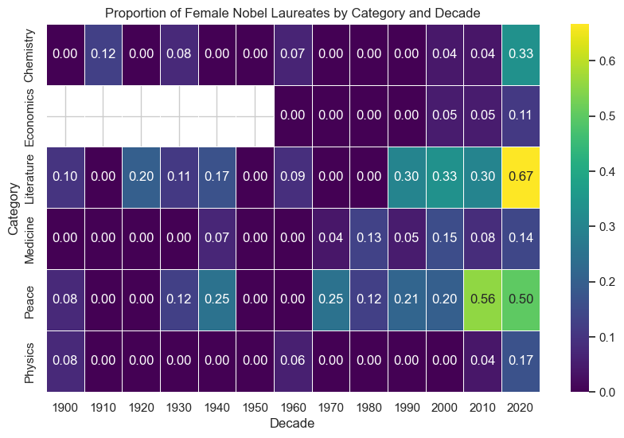

```python
plt.figure(figsize=(10,6))

sns.heatmap(female_pivot, annot=True, fmt=".2f", linewidths=0.5, cmap="viridis")

plt.title("Proportion of Female Nobel Laureates by Category and Decade")
plt.xlabel("Decade")
plt.ylabel("Category")

plt.show()
```

> Blank cells appear for the Economics category in early decades because the Nobel Prize in Economics was introduced in 1969. Therefore, no awards were given in that category before that period.

> **Insight:** The **2020s decade in the Literature** category shows the highest proportion of female laureates, reaching approximately **66.7%**. Historically, female representation has been very low in scientific fields such as **Physics and Chemistry**. In contrast, categories like **Literature and Peace** show relatively higher participation of women. The heatmap also reveals a gradual increase in female representation beginning in the late 20th century, suggesting improving gender diversity in Nobel Prize recognition.

## 7) Q5) Who was the first woman to win a Nobel Prize and in which category?

### Filter female laureates

```python
first_woman = data[data["sex"] == "Female"].sort_values("year").iloc[0]

first_woman
```

```
year                                                                 1903
category                                                          Physics
prize                                     The Nobel Prize in Physics 1903
motivation              "in recognition of the extraordinary services ...
prize_share                                                           1/4
laureate_id                                                             6
laureate_type                                                  Individual
full_name                                     Marie Curie, née Sklodowska
birth_date                                                     1867-11-07
birth_city                                                         Warsaw
birth_country                                     Russian Empire (Poland)
sex                                                                Female
organization_name                                                     NaN
organization_city                                                     NaN
organization_country                                                  NaN
death_date                                                     1934-07-04
death_city                                                     Sallanches
death_country                                                      France
decade                                                               1900
US_born                                                             False
female                                                               True
Name: 19, dtype: object
```

```python
first_woman_name = first_woman["full_name"]

first_woman_category = first_woman["category"]

first_woman_year = first_woman["year"]

print(first_woman_name,"-", first_woman_category, "(", first_woman_year, ")")
```

```
Marie Curie, née Sklodowska - Physics ( 1903 )
```

> **Insight:**

The first woman to receive a Nobel Prize was Marie Curie, who won the 1903 Nobel Prize in Physics for her pioneering research on radiation. The dataset also shows that she later received the 1911 Nobel Prize in Chemistry, becoming the first person to win Nobel Prizes in two different scientific disciplines.

## 8) Q6) Which individuals have won multiple Nobel Prizes?

### Count Nobel Prizes per Laureate

```python
# Count how many times each name appears in the dataset
winner_counts = data["full_name"].value_counts()
winner_counts
```

```
full_name
Linus Carl Pauling              2
Marie Curie, née Sklodowska     2
Frederick Sanger                2
John Bardeen                    2
Jacobus Henricus van 't Hoff    1
                               ..
John Cowdery Kendrew            1
John Steinbeck                  1
Francis Harry Compton Crick     1
James Dewey Watson              1
Claudia Goldin                  1
Name: count, Length: 958, dtype: int64
```

### Identify Multiple Winners

```python
# Select winners with more than one prize
repeat_winners = winner_counts[winner_counts>1]
```

### Extract Names

```python
# Extract only the names
repeat_list = repeat_winners.index.tolist()

repeat_list
```

```
['Linus Carl Pauling',
 'Marie Curie, née Sklodowska',
 'Frederick Sanger',
 'John Bardeen']
```

> **Insight:**

A small number of individuals have received multiple Nobel Prizes. These include **Marie Curie, Linus Pauling, Frederick Sanger, and John Bardeen**, each of whom won the Nobel Prize twice. This repeated recognition highlights exceptional scientific contributions across different disciplines.

### Visualization Using Seaborn

```python
repeat = repeat_winners.reset_index()
repeat
```

|  | full_name | count |
| --- | --- | --- |
| 0 | Linus Carl Pauling | 2 |
| 1 | Marie Curie, née Sklodowska | 2 |
| 2 | Frederick Sanger | 2 |
| 3 | John Bardeen | 2 |

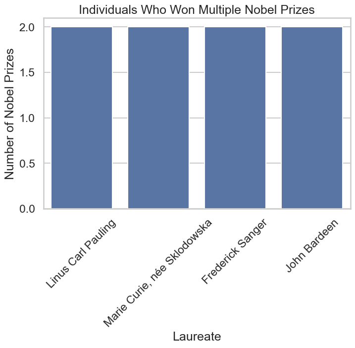

```python
sns.set_theme(style="whitegrid", context="talk")

plt.figure(figsize=(8,5))

sns.barplot (data =repeat, x="full_name", y="count" )

plt.title("Individuals Who Won Multiple Nobel Prizes")
plt.ylabel("Number of Nobel Prizes")
plt.xlabel("Laureate")
plt.xticks(rotation=45)

plt.show()
```

## 9) Q7) How has female representation among Nobel Prize winners evolved over time?

### Yearly Trend of Female Representation

> Short-term variation → shows variability and many zero years

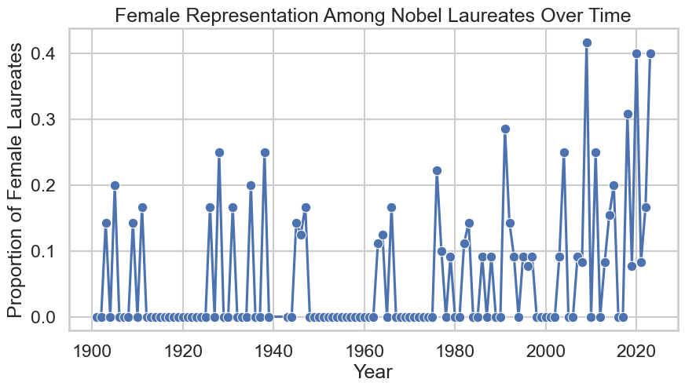

```python
# the proportion of female winners per year
# Now the column female = proportion of women that year.
female_trend = data.groupby("year")["female"].mean().reset_index()

plt.figure(figsize=(10,5))

sns.lineplot( data = female_trend, x = "year", y = "female", marker = "o")

plt.title("Female Representation Among Nobel Laureates Over Time")
plt.xlabel("Year")
plt.ylabel("Proportion of Female Laureates")


plt.show()
```

> **Insight:** Because yearly values fluctuate significantly due to the small number of laureates per year, the data is aggregated by decade to better reveal the long-term trend.

### Decade-Level Trend

> Long-term trend → reveals the long-term increase in female participation

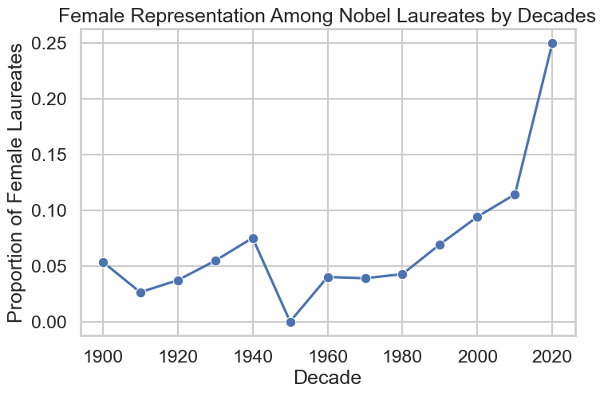

```python
# the proportion of female winners per year
# Now the column female = proportion of women that year.
female_trend_decade = data.groupby("decade")["female"].mean().reset_index()

plt.figure(figsize=(8,5))

sns.lineplot( data = female_trend_decade, x = "decade", y = "female", marker="o")

plt.title("Female Representation Among Nobel Laureates by Decades")
plt.xlabel("Decade")
plt.ylabel("Proportion of Female Laureates")


plt.show()
```

> **Insight:** Aggregating the data by decade reveals a clearer long-term trend. Female representation among Nobel laureates remained extremely low throughout most of the 20th century but begins to increase steadily after the 1980s. The most recent decades show the highest proportions of female laureates, suggesting gradual progress in recognizing women's contributions across Nobel Prize categories.

## 10) Q8) Which Nobel Prize categories show the largest gender disparities?

## male = 1 - female

```python
# male proportion = 1 - female proportion

# female proportion per category

gender_disparity = data.groupby("category")["female"].mean().sort_values()
gender_disparity
```

```
category
Physics       0.022321
Economics     0.032258
Chemistry     0.041885
Medicine      0.057522
Literature    0.144068
Peace         0.172727
Name: female, dtype: float64
```

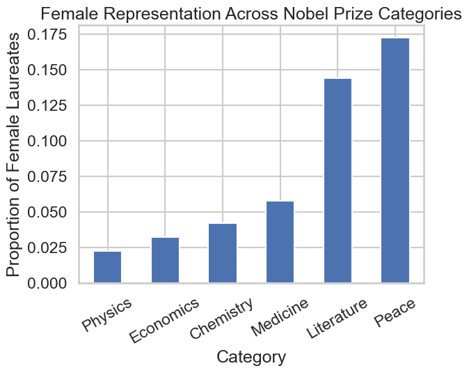

```python
gender_disparity.plot(kind="bar")

plt.title("Female Representation Across Nobel Prize Categories")
plt.xlabel("Category")
plt.ylabel("Proportion of Female Laureates")
plt.xticks(rotation=30)

plt.show()
```

> **Insights:** Female representation varies considerably across Nobel Prize categories. Peace and Literature show the highest proportions of female laureates, while Physics, Economics, and Chemistry have the lowest representation. This indicates that gender disparities remain most pronounced in traditionally male-dominated scientific fields.

## 11) Findings

- **Male laureates dominate Nobel Prize history**, with female representation remaining low for most of the 20th century
- The **United States emerges as the leading country** in terms of Nobel Prize winners
- The **2000s show the highest proportion of U.S.-born laureates**, indicating growing dominance in recent decades
- **Marie Curie** was the first female Nobel Prize winner and remains one of the few multiple-time winners
- Only a **small group of individuals have won multiple Nobel Prizes**, highlighting exceptional contributions
- Female representation **increases significantly after the 1990s**, although it remains uneven
- **Peace and Literature** show the highest female participation
- **Physics, Economics, and Chemistry** exhibit the **largest gender disparities**, with very low female representation

## 12) Appendix - Alternative Approaches and plots

## Appendix 1 – Alternative Approaches for Q5: Identify the First Female Nobel Laureate

> The same result can be obtained using different pandas techniques. The following examples demonstrate three alternative approaches for identifying the first female Nobel Prize Laureate

### Method 1: Sorting by Year

1️⃣ `sort_values() + iloc`

```python
first_woman = data[data["female"]].sort_values("year").iloc[0]

first_woman_name = firstwoman["full_name"]

first_woman_category = firstwoman["category"]

first_woman_year = firstwoman["year"]

print(first_woman_name,"-", first_woman_category, "(", first_woman_year, ")")
```

[output not shown]

### Method 2: Using idxmin() to Locate the Earliest Year

2️⃣ `idxmin() + loc`

```python
# idxmin() returns the index where the minimum value occurs.
# Using .loc retrieves the entire row of the dataset.

first_woman = data.loc[data[data["female"]]["year"].idxmin()]

first_woman[["full_name","category","year"]]
```

```
full_name    Marie Curie, née Sklodowska
category                         Physics
year                                1903
Name: 19, dtype: object
```

### Method 3: Use nsmallest() to retrieve the Earliest Record

3️⃣ `nsmallest()`

```python
first_woman = data[data["female"]].nsmallest(1, "year")

first_woman[["full_name","category","year"]]
```

|  | full_name | category | year |
| --- | --- | --- | --- |
| 19 | Marie Curie, née Sklodowska | Physics | 1903 |

## Appendix 2 – Alternative Visualization for Q6 (Pandas Plot)

> The same visualization can also be generated using pandas' built-in plotting functionality without relying on seaborn. This approach is shown here as an alternative implementation.

> repeat_winners is a Series where:

> > index → laureate names → x-axis

> > values → number of prizes → y-axis

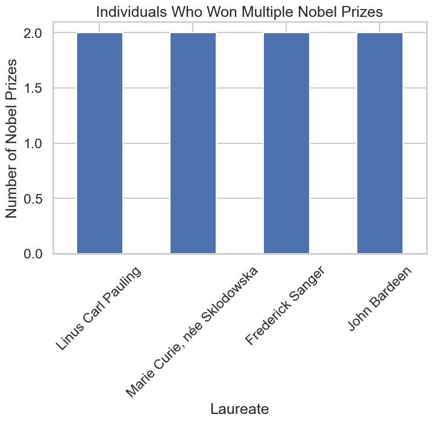

```python
plt.figure(figsize=(8,5))

repeat_winners.plot(kind="bar")

plt.title("Individuals Who Won Multiple Nobel Prizes")
plt.ylabel("Number of Nobel Prizes")
plt.xlabel("Laureate")
plt.xticks(rotation=45)

plt.show()
```

## Appendix 3 – Alternative Visualizations and Tables for Q8

### Method 1: Visualization Using Seaborn Bar Plot

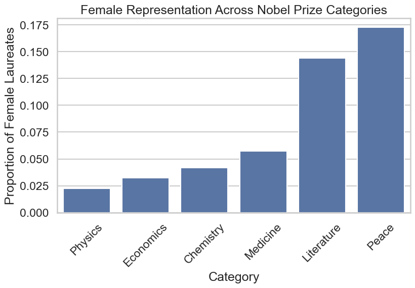

```python
sns.set_style("whitegrid")

plt.figure(figsize=(9,5))

category_female = gender_disparity.reset_index()

sns.barplot(data=category_female, x="category", y= "female")

plt.title("Female Representation Across Nobel Prize Categories")
plt.xlabel("Category")
plt.ylabel("Proportion of Female Laureates")
plt.xticks(rotation=45)

plt.show()
```

> The same analysis can also be visualized using Seaborn's barplot function. This alternative implementation produces a similar result but relies on Seaborn's built-in plotting capabilities instead of pandas' built-in plotting.

### Method 2: Female + Male Proportion Table

```python
data["male"] = data["sex"] == "Male"

# Compute Female and Male Proportions per category
Gender_Disparity = data.groupby("category")[["female", "male"]].mean()
Gender_Disparity
```

| category | female | male |
| --- | --- | --- |
| Chemistry | 0.041885 | 0.958115 |
| Economics | 0.032258 | 0.967742 |
| Literature | 0.144068 | 0.855932 |
| Medicine | 0.057522 | 0.942478 |
| Peace | 0.172727 | 0.827273 |
| Physics | 0.022321 | 0.977679 |

### Method 3: Female + Male Comparison Plot

#### reshape table to long format for grouped seaborn barplot

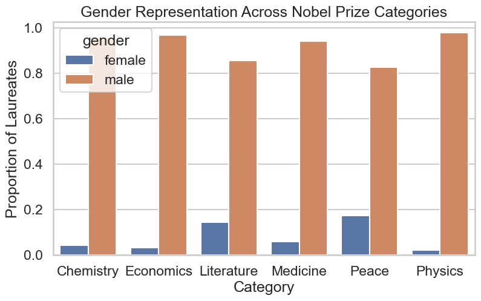

```python
gender_ratio_long = gender_ratio.melt(
    id_vars="category",
    value_vars=["female","male"],
    var_name="gender",
    value_name="proportion"
)

plt.figure(figsize=(9,5))


sns.set_style("whitegrid")
sns.barplot( data=gender_ratio_long, x="category", y="proportion", hue="gender")

plt.title("Gender Representation Across Nobel Prize Categories")
plt.xlabel("Category")
plt.ylabel("Proportion of Laureates")

plt.show()
```

Back to top